# GDP Population Trends & Electric Source Distribution

Muge Kosar

28 April 2022

# 1 Introduction

This report analyzes the energy dataset which includes variables on electricity sources, and energy production consumption including GDP-population variables. The various methods are applied to analyze: - Relationship between the population and some electricity sources - GDP-Population trends - Percentage Change in GDP, GDP per capita and Population - Electricity source distributions - Energy distribution in 1990 and 2018 for Japan and Germany

# 2 Data

```r
# Filter on needed variables.
data<-select(merged_data,country,year,coal_production,electricity_generation,biofuel_electricity,coal_electricity,fossil_electricity,gas_electricity,hydro_electricity,nuclear_electricity,oil_electricity,renewables_electricity,oil_production,population,gdp,solar_electricity,wind_electricity,energy_per_gdp,energy_per_capita,fossil_share_elec,gas_share_elec,gas_production,low_carbon_share_elec)
# Filter on year.
data<-filter(data,data$year>=1990)
# Filter on countries.
data<-
  data %>%
  filter(country=="Egypt" |
         country=="Saudi Arabia" |
         country=="United Kingdom" |
         country=="France" |
         country=="Germany" |
         country=="United States" |
         country=="Japan" |
         country=="India" |
         country=="Algeria" |
         country=="Belgium" |
         country=="Finland" |
         country=="Hungary" |
         country=="Italy" |
         country=="Poland" |
         country=="Spain" |
         country=="Turkey")

#Replace NA values with 0
data[is.na(data)]=0
```

# 3 Summary statistics

```
##    country               year      coal_production   electricity_generation
##  Length:462         Min.   :1990   Min.   :   0.00   Min.   :  16.1
##  Class :character   1st Qu.:1997   1st Qu.:   0.00   1st Qu.:  83.7
##  Mode  :character   Median :2004   Median :  18.71   Median : 242.9
##                     Mean   :2004   Mean   : 660.27   Mean   : 555.4
##                     3rd Qu.:2011   3rd Qu.: 494.35   3rd Qu.: 555.5
##                     Max.   :2020   Max.   :6694.61   Max.   :4203.9
##  biofuel_electricity coal_electricity   fossil_electricity gas_electricity
##  Min.   : 0.00       Min.   :   0.000   Min.   :   0.00    Min.   :   0.00
##  1st Qu.: 0.06       1st Qu.:   7.085   1st Qu.:  42.14    1st Qu.:  11.99
##  Median : 1.73       Median :  36.065   Median : 143.77    Median :  47.47
##  Mean   : 8.30       Mean   : 211.474   Mean   : 365.46    Mean   : 119.24
##  3rd Qu.: 8.64       3rd Qu.: 192.082   3rd Qu.: 352.80    3rd Qu.: 104.97
##  Max.   :63.99       Max.   :2037.863   Max.   :3004.47    Max.   :1629.24
##  hydro_electricity nuclear_electricity oil_electricity  renewables_electricity
##  Min.   :  0.000   Min.   :  0.00      Min.   :  0.00   Min.   :  0.00
##  1st Qu.:  1.685   1st Qu.:  0.00      1st Qu.:  4.58   1st Qu.:  3.31
##  Median : 17.550   Median : 22.39      Median : 11.74   Median : 27.79
##  Mean   : 45.152   Mean   :114.60      Mean   : 34.75   Mean   : 74.38
##  3rd Qu.: 59.300   3rd Qu.: 89.25      3rd Qu.: 30.13   3rd Qu.: 87.39
##  Max.   :355.973   Max.   :809.41      Max.   :287.54   Max.   :827.94
##  oil_production     population              gdp
##  Min.   :   0.0   Min.   :   4996220   Min.   :  108000000000
##  1st Qu.:   0.0   1st Qu.:  30948012   1st Qu.:  378310365801
##  Median :   0.0   Median :  58375782   Median : 1355000000000
##  Mean   : 841.8   Mean   : 140383769   Mean   : 2390122046860
##  3rd Qu.: 538.4   3rd Qu.:  81438445   3rd Qu.: 2497500000000
##  Max.   :8670.2   Max.   :1380004385   Max.   :19974534312000
##  solar_electricity wind_electricity   energy_per_gdp  energy_per_capita
##  Min.   :  0.000   Min.   :  0.0000   Min.   :0.000   Min.   :    0
##  1st Qu.:  0.000   1st Qu.:  0.0013   1st Qu.:1.124   1st Qu.:18607
##  Median :  0.010   Median :  0.5560   Median :1.468   Median :38489
##  Mean   :  4.282   Mean   : 12.8376   Mean   :1.535   Mean   :39977
##  3rd Qu.:  0.531   3rd Qu.:  6.5275   3rd Qu.:1.885   3rd Qu.:52228
##  Max.   :132.630   Max.   :336.5330   Max.   :4.246   Max.   :94883
##  fossil_share_elec gas_share_elec   gas_production    low_carbon_share_elec
##  Min.   :  0.00    Min.   : 0.000   Min.   :   0.00   Min.   : 0.00
##  1st Qu.: 49.11    1st Qu.: 9.098   1st Qu.:   0.00   1st Qu.:17.87
##  Median : 68.49    Median :19.682   Median :  59.59   Median :30.52
##  Mean   : 64.19    Mean   :26.484   Mean   : 568.30   Mean   :33.63
##  3rd Qu.: 81.15    3rd Qu.:39.400   3rd Qu.: 428.48   3rd Qu.:48.19
##  Max.   :100.00    Max.   :99.785   Max.   :9208.82   Max.   :93.70
```

# 4 Regression Analysis

To check if the result is statistically significant, I used the probability value which means the test is statistically significant if probability value is lower than 0.05. Then, I interpreted the results according to their coefficients. It means a positive sign indicates that as the independent variable increases, the dependent variable also increases while a negative sign indicates that as the independent variable increases, the dependent variable decreases.

[output not shown]

* p < 0.1, ** p < 0.05, *** p < 0.01

# 5 GDP vs Pop Trends

Based on Figures below:

United States has the highest GDP and highest GDP per capita while Egypt has the lowest GDP. Although India has the second-highest GDP, it has the lowest GDP per capita. The highest population is in India while the lowest population is in Saudi Arabia.

## 5.1 Line chart for GDP per capita

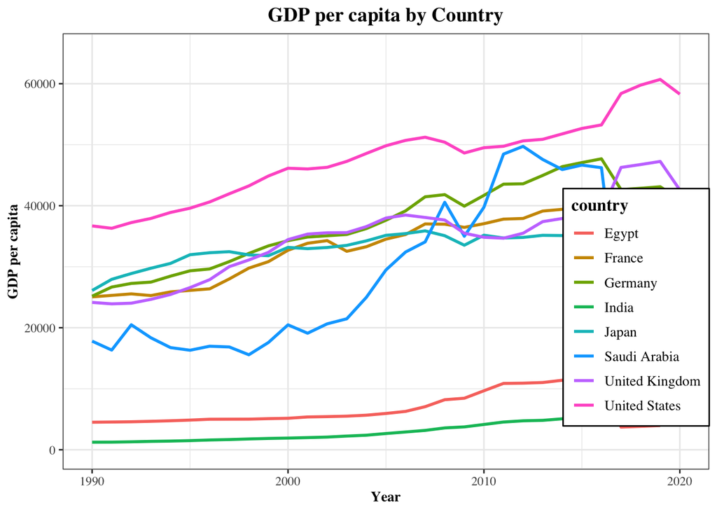

## 5.2 Line chart for GDP

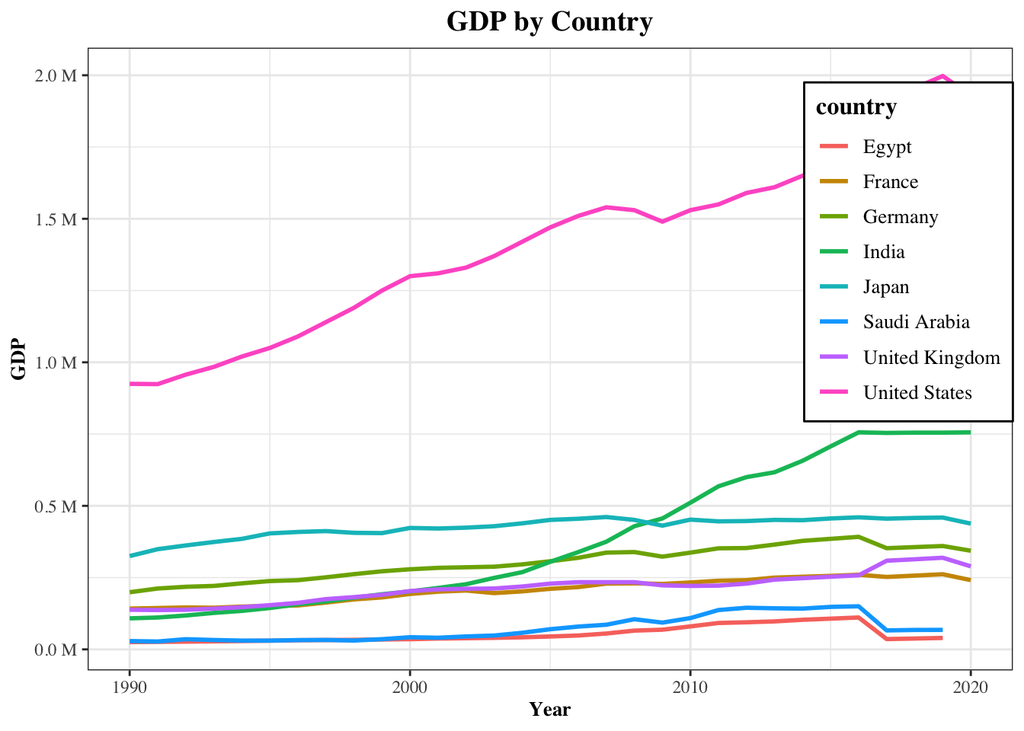

## 5.3 Line chart for Population

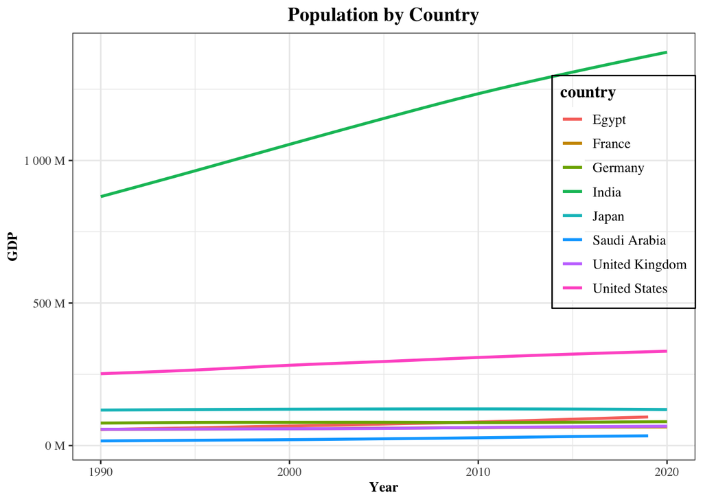

# 6 Percentage Changes in GDP ,Population and GDP per capita

Based on Figures below:

The highest percentage increase in GDP is in Saudi Arabia which is 171.05% while the lowest percentage change in GDP is in Japan which is 4.45%. Population percentage change figure shows that there is no population increase in Germany which is -0.45% and Japan has little population increase which is 0.29%. According to the figure for GDP per capita percentage change, the highest percentage increase in GDP per capita is in India while the lowest percentage increase in GDP per capita is in the United Kingdom.

## 6.1 GDP % increase

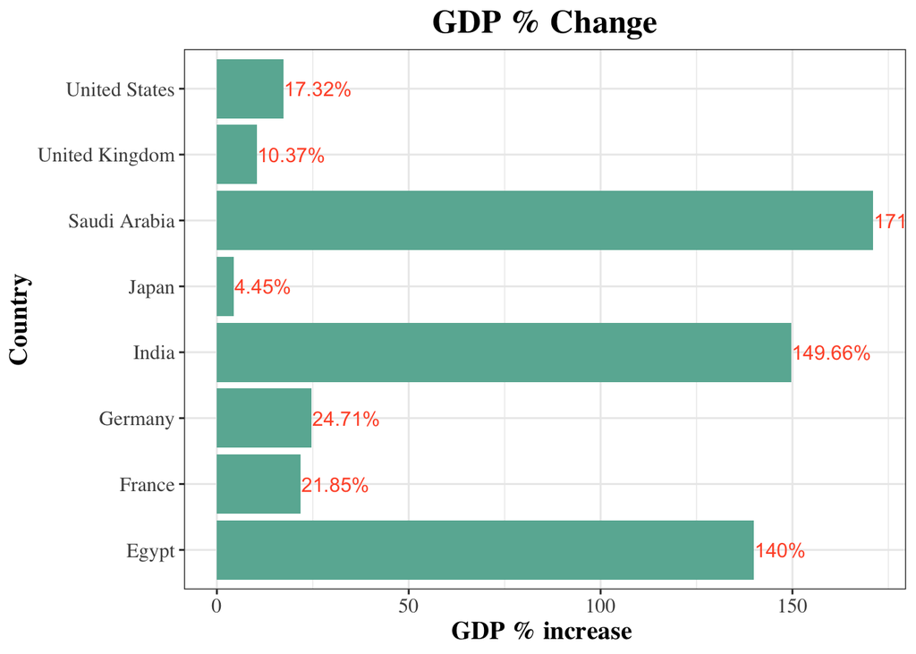

## 6.2 Population % increase

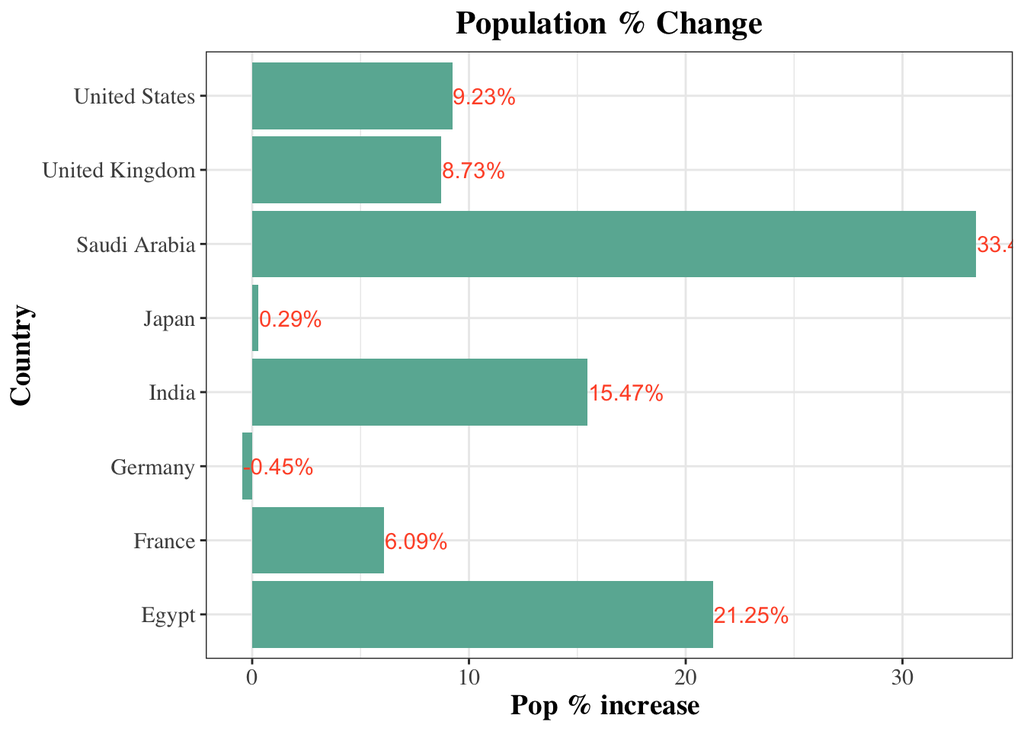

## 6.3 GDP per capita % increase

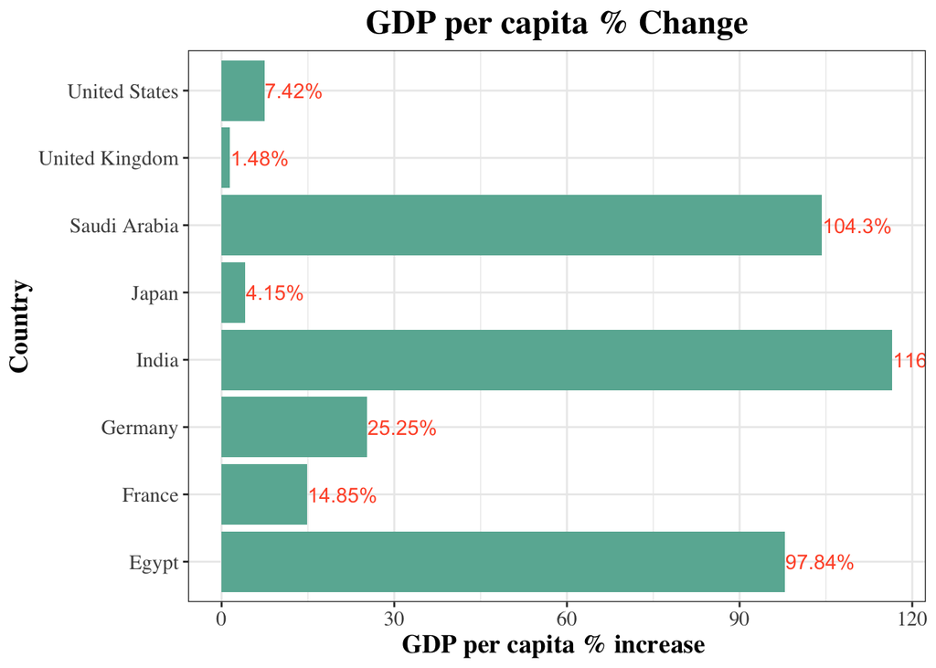

# 7 Percentage share of electricty from total energy sources (Japan)

According to the Japan electricity source distribution graph, after 2011 coal and gas share increased but nuclear energy decreased.

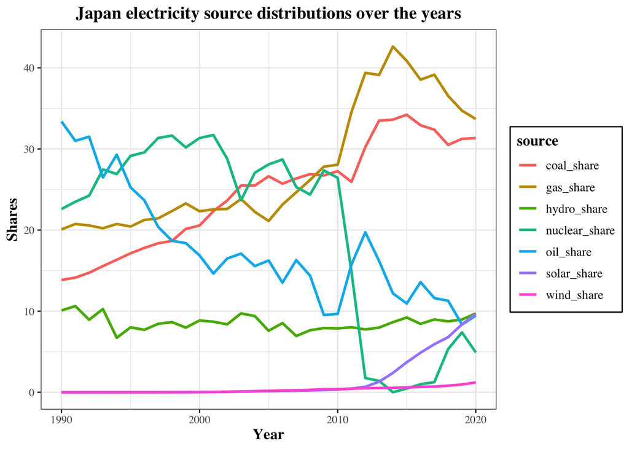

# 8 Plotting pie chart for energy distribution and comparing 1990 Vs 2018 (Japan)

For Japan, in 1990 primary energy source is oil, and second-highest share in electricity distribution is nuclear energy with 22.59%. In 2018, the pie chart shows that Japan changed its strategy for energy sources and became more reliant on coal and gas.

## 8.1 Pie chart for 1990

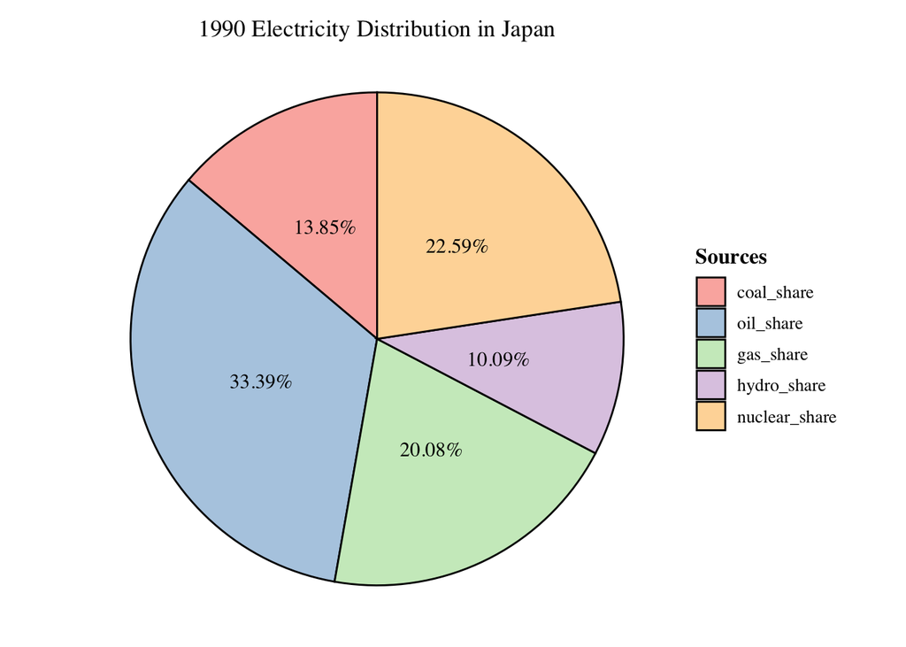

## 8.2 Plotting pie chart for 2018

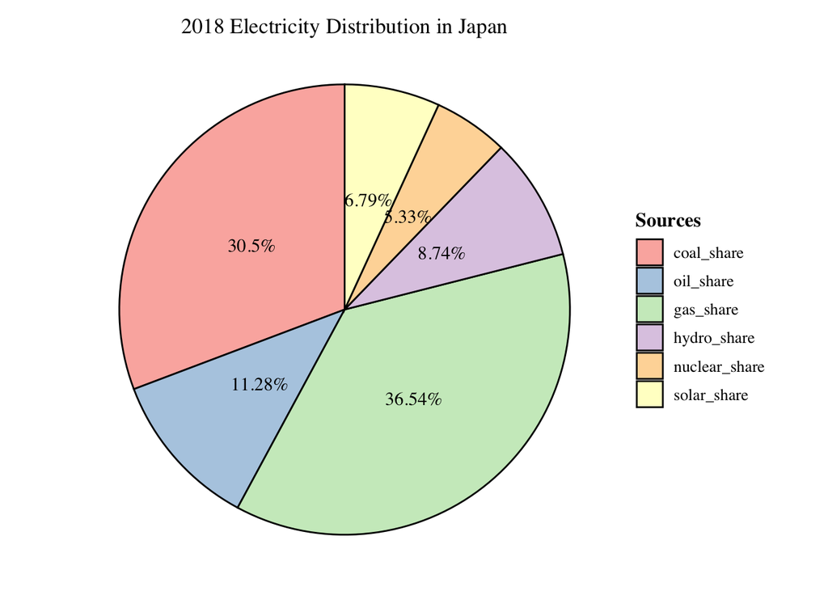

# 9 Percentage share of electricty from total energy sources (Germany)

According to the German electricity source distribution graph, Germany also reduced its reliance on nuclear energy, and after 2015 wind has the second-highest share.

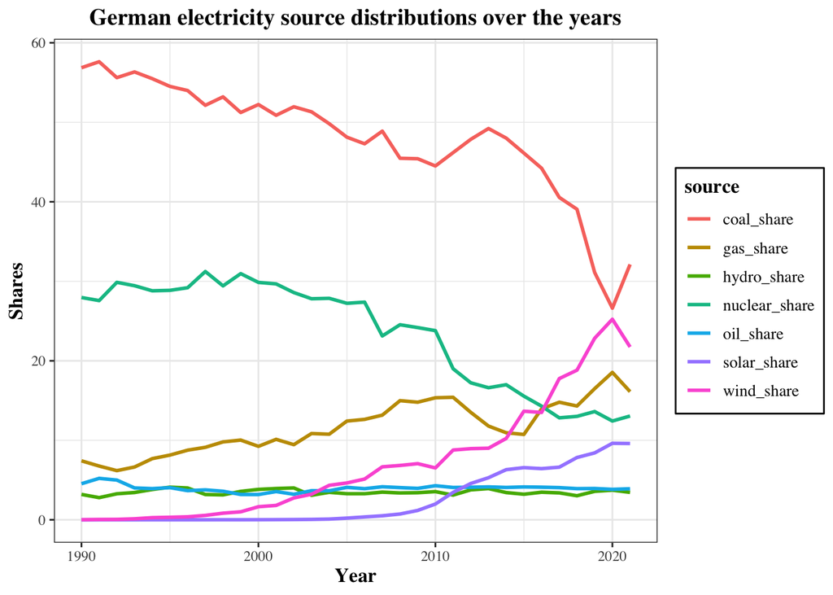

# 10 Plotting pie chart for energy distribution and comparing 1990 Vs 2018 (Germany)

For Germany in 1990 highest share in energy distribution is coal with 56.87% and second highest share is nuclear energy while lowest share in energy distribution is hydro with 3.2%. In 2018, pie chart shows that Germany changed its strategy for energy sources to renewable sources and wind energy became second primary energy source.

## 10.1 Pie chart for 1990

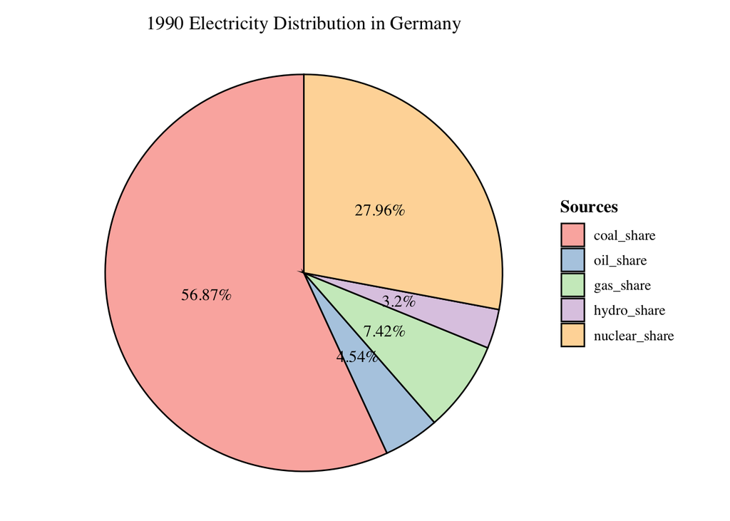

## 10.2 Pie chart for 2018

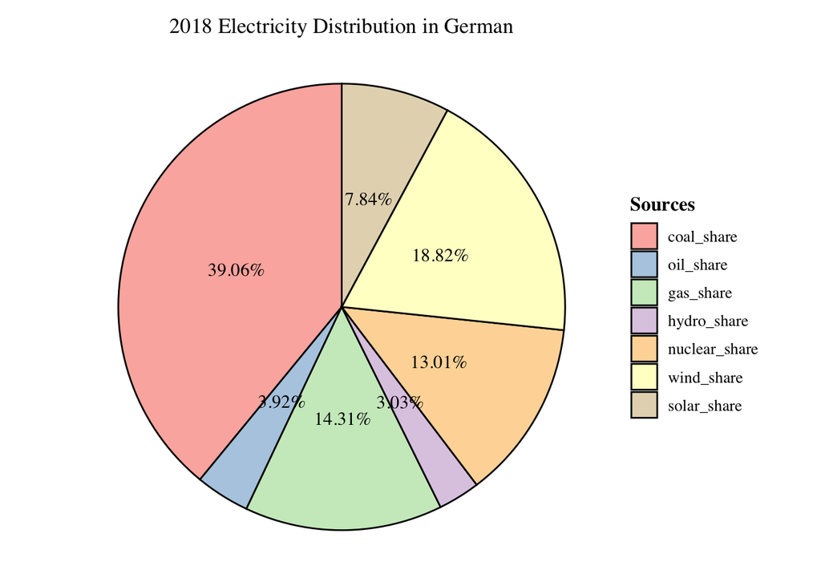

# 11 Conclusion

The findings from regression analysis show that not controlling for gas production created omitted variable bias which means it is correlated with population and coal production.

Overall, GDP-Population trends shows that the situation in Japan and Germany is highly concerning. They have no population increase and that means the ratio of young working population to old retired will be less in the near future. The GDP will be affected as the workforce decreases. Germany is welcoming more refugees to resolve this issue. Maybe Japan should find solutions to resolve this issue soon. Egypt is doing well in terms of GDP per capita increase which is 97.84%. Perhaps if the population increase was less, the impact will be more noticeable.

Electricity source distribution analysis demonstrates that Japan decreased nuclear electricity usage after 2011 when happened Fukushima nuclear disaster-4 reactor buildings exploded. Thus, Japan changed its strategy for energy sources and became more reliant on coal and gas. (Chart 1-2) Germany is also affected from this disaster in Japan, so Germany also reduced its reliance on nuclear energy. The charts show that Germany also changed its strategy for energy sources to renewable sources.